# Data analysis with R and the tidyverse

## 5.6 Box plots

Box plots are very powerful statistical tools that summarize the most important aspects of a variable’s distribution:

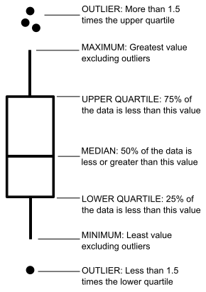

The x-axis in a box plot is usually a categorical variable and the y-axis is normally a numeric variable who’s distribution we want to explore. For example, let’s visualize the distribution of High Density Lipoprotein values for males and females in **diab**:

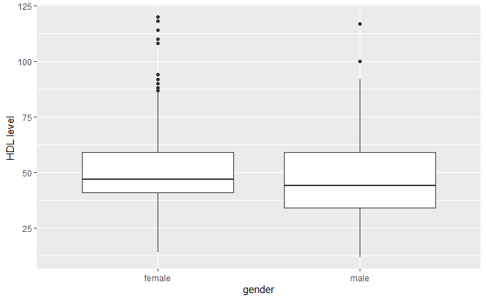

```r
diab %>%
  ggplot(aes(x = gender, y = hdl)) +
  geom_boxplot() +
  xlab("gender") +
  ylab("HDL level ")
```

## 5.7 Histograms and densities

Histograms work on a single variable and show how it is distributed by dividing its range into a certain number of bins. Thus, the x-axis reports the values that the variable can take (binned) and the y-axis reports the number or fraction of observations that take such values.

Let’s look at the distribution of Stabilized glucose values, specifying the width of the histogram bins with parameter **binwidth**:

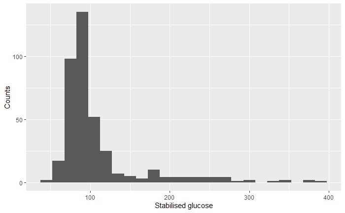

```r
diab %>%
  ggplot(aes(x = stab.glu)) +
  geom_histogram(binwidth = 15) +
  xlab("Stabilised glucose") +
  ylab("Counts")
```

We can also put two histograms in the same plot:

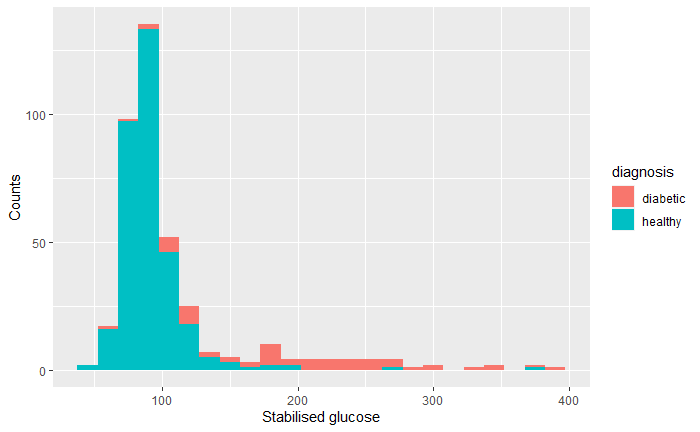

```r
diab %>%
  group_by(diagnosis) %>%
  ggplot(aes(x = stab.glu, fill = diagnosis)) +
  geom_histogram(binwidth = 15) +
  xlab("Stabilised glucose") +
  ylab("Counts")
```

Density plots are like regressions but for histograms. Density plots try to find the curve that best summarizes the distribution of a variable and report probability densities instead of counts. To control the smoothing of the density plot, we use parameter **adjust**:

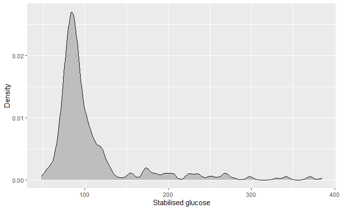

```r
diab %>%
  ggplot(aes(x = stab.glu)) +
  geom_density(adjust = 0.7, fill = 'grey') +
  xlab("Stabilised glucose") +
  ylab("Density")
```

## 5.8 Facets

Ggplot’s facets are a powerful feature that subdivides a plot in subplots according to given variables (categories). There are 2 main functions to create the subplots: **facet_wrap** and **facet_grid**.

For example, the density plot can be subdivided by gender (it also works for other types of plots):

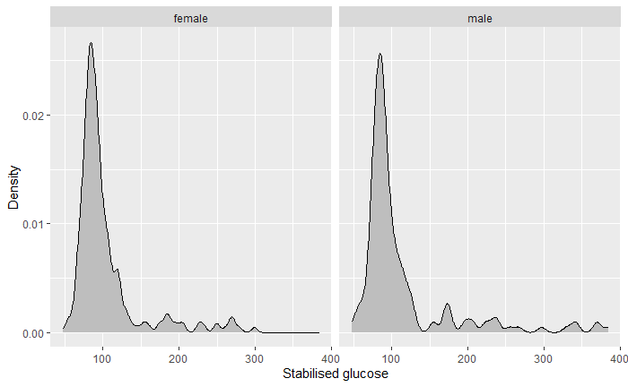

```r
diab %>%
  ggplot(aes(x = stab.glu)) +
  geom_density(adjust = 0.7, fill='grey') +
  facet_wrap(vars(gender)) +
  xlab("Stabilised glucose") +
  ylab("Density")
```

You can provide a list of columns to the facets function such as gender and location:

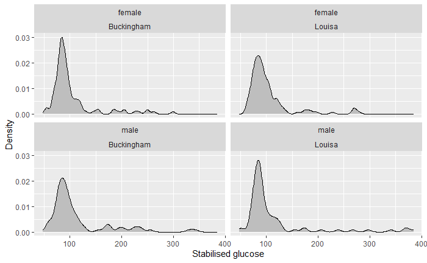

```r
diab %>%
  ggplot(aes(x = stab.glu)) +
  geom_density(adjust = 0.7, fill='grey') +
  facet_wrap(vars(gender, location)) +
  xlab("Stabilised glucose") +
  ylab("Density")
```

You can combine facets with the **fill** parameter of **aes** (not using anymore **fill** in **geom_density**) to create subplots by gender and location, and to compare the diagnosis in each subplot:

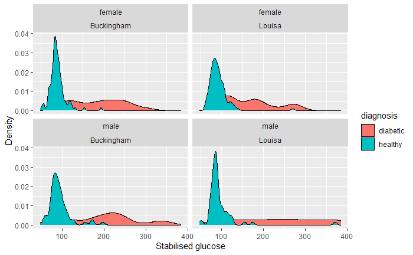

```r
diab %>%
  ggplot(aes(x = stab.glu, fill=diagnosis)) +
  geom_density(adjust = 0.7) +
  facet_wrap(vars(gender, location)) +
  xlab("Stabilised glucose") +
  ylab("Density")
```

Finally, facets can be displayed as a grid using facet_grid. Using the example below, one can compare the distributions of male and female HDL levels in relation to the diagnosis and location:

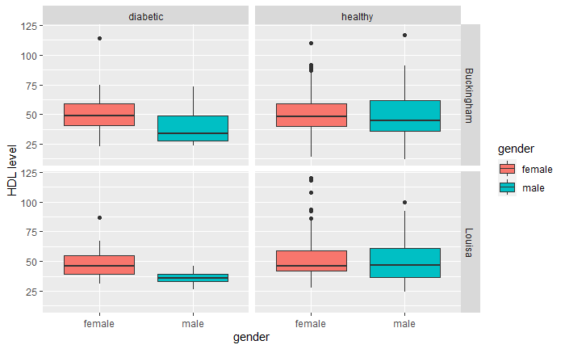

```r
diab %>%
  ggplot(aes(x = gender, y = hdl, fill=gender)) +
  geom_boxplot() +
  facet_grid(rows=vars(location), cols=vars(diagnosis)) +
  xlab("gender") +
  ylab("HDL level ")
```

## 5.9 A simple model

In Exercise 5.1, you used Glycosolated haemoglobin levels above 7.0 to diagnose diabetes. The histograms from the previous section showed that diabetics have bigger levels of Stabilized glucose compared to healthy subjects.

### 5.9.1 Exercise 5.2

1. Generate a scatter plot comparing **glyhb** with **stab.glu** using the subject diagnosis as the point color.
2. Use facets to create subplots to observe the data by location and gender.
3. Do you observe differences between the subpopulations of patients?